# Beta diversity of microbes during inulin treatment

## 6b. NMDS: Non-Metric Multidimensional Scaling

```r
## SORENSEN
scaled_soren_nmds <-
  ordinate(physeq = scaled_physeq,
         method = "NMDS",
         distance = "bray", binary = TRUE)
```

```
## Square root transformation
## Wisconsin double standardization
## *** Best solution was not repeated -- monoMDS stopping criteria:
##      3: no. of iterations >= maxit
##     17: stress ratio > sratmax
```

```r
# Plot it!
sorensen_nmds_plot <-
  plot_ordination(physeq = scaled_physeq,
                ordination = scaled_soren_nmds,
                color = "status",
                title = "Sorensen NMDS") +
  scale_color_manual(values = status_colors) +
  scale_shape_manual(values = c(15, 16, 17)) +
  geom_point(size = 5, alpha = 0.5, aes(color = status)) +
  theme_bw() +
  theme(legend.position = "right")

### Bray-Curtis
# Second, calculate NMDS with Bray-Curtis
scaled_bray_nmds <-
  ordinate(physeq = scaled_physeq,
         method = "NMDS",
         distance = "bray", binary = FALSE)
```

```
## Square root transformation
## Wisconsin double standardization
## *** Best solution was not repeated -- monoMDS stopping criteria:
##      4: no. of iterations >= maxit
##     16: stress ratio > sratmax
```

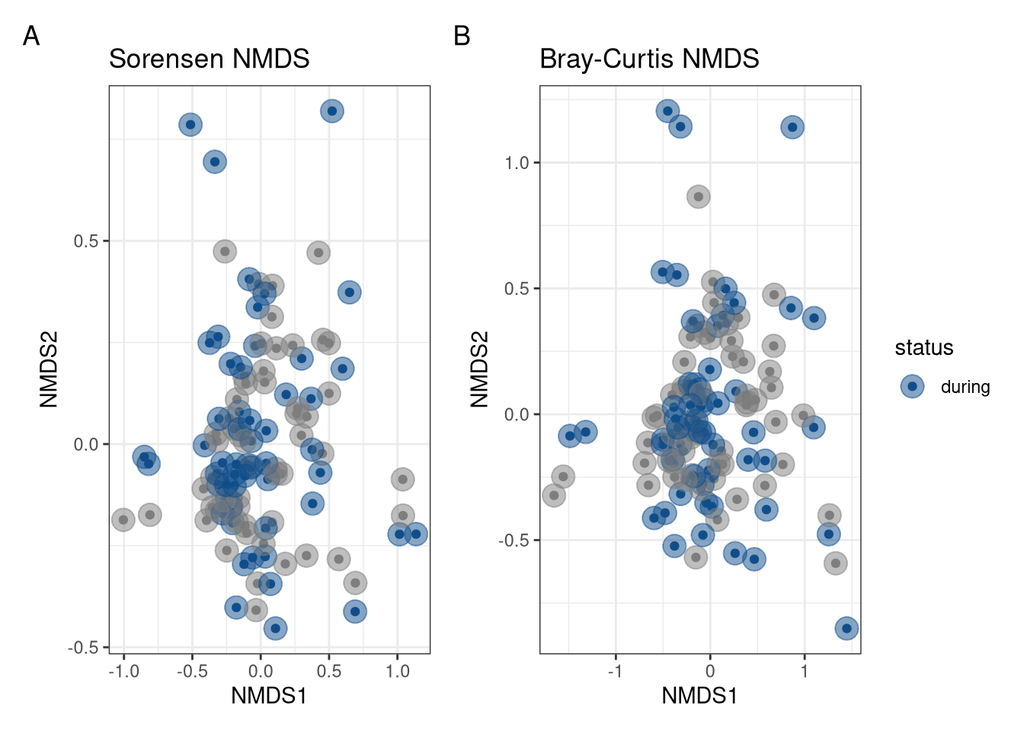

```r
# Plot it: Bray-Curtis NMDS
bray_nmds_plot <-
  plot_ordination(physeq = scaled_physeq,
                ordination = scaled_bray_nmds,
                color = "status",
                title = "Bray-Curtis NMDS") +
  scale_color_manual(values = status_colors) +
  scale_shape_manual(values = c(15, 16, 17)) +
  geom_point(size = 5, alpha = 0.5, aes(color = status)) +
  theme_bw() +
  theme(legend.position = "right")

# Show the plots
sorensen_nmds_plot + bray_nmds_plot +
  plot_layout(guides = "collect") +
  plot_annotation(tag_levels = "A")
```

INTERPRETATION #9: Plot your data using NMDS. Interpret what you can conclude from the NMDS.

## All ordinations together!

[figure not shown]

```r
sorensen_pcoa_plot + bray_pcoa_plot +
sorensen_nmds_plot + bray_nmds_plot +
  plot_layout(guides = "collect") +
  plot_annotation(tag_levels = "A")
```

INTERPRETATION #10: Plot both the PCoA and NMDS together. Which of the two visualizations work best for your data? Explain your reasoning.

Neither plot shows a strong correlation to the treatment groups, but PCoA has better potential at explaining the differences in the data with some trends and directionality observed. Bray curtis PCoA showed clustering around the top right with a noticeable gradient possibly related to SCFA levels, NMDS showd clustering but most samples were overlapping with no clear trends.

# Final info for Reproducibility

## Check Render Time

```r
# Take the time now that we are at the end of the script
end_time <- Sys.time()
end_time
```

```
## [1] "2025-05-02 02:38:08 EDT"
```

```r
# Echo the elapsed time
elapsed_time <- round((end_time - start_time), 3)
elapsed_time
```

```
## Time difference of 21.435 secs
```